# week09_in_class

```python
import numpy as np
import matplotlib.pyplot as plt
```

```python
myarray = np.random.random((100,100))
myarray
```

```
array([[0.91657369, 0.12594987, 0.40169113, ..., 0.83881997, 0.48820168,
        0.53937214],
       [0.0177309 , 0.51942789, 0.40519709, ..., 0.87154534, 0.1199704 ,
        0.25518274],
       [0.75200433, 0.12348689, 0.49356397, ..., 0.508232  , 0.32153046,
        0.21364882],
       ...,
       [0.53116462, 0.57032553, 0.84346767, ..., 0.91615314, 0.96983441,
        0.2745283 ],
       [0.39891037, 0.553728  , 0.82585018, ..., 0.15887506, 0.67723117,
        0.24871434],
       [0.95974306, 0.39428487, 0.79456226, ..., 0.53244956, 0.71358808,
        0.37109127]])
```

```python
myarray[48:52,44:48]
```

```
array([[0.02302951, 0.50818176, 0.2926425 , 0.23782411],
       [0.13698988, 0.5619801 , 0.8700189 , 0.04930972],
       [0.16062882, 0.49102689, 0.7432226 , 0.64694582],
       [0.73635555, 0.55168451, 0.84451052, 0.81117496]])
```

```python
myarray[[1,2,4],:] # row 1,2,4; all cols
```

```
array([[1.77308973e-02, 5.19427893e-01, 4.05197088e-01, 3.97451354e-01,
        2.45898102e-01, 1.44084703e-01, 8.00855259e-01, 7.94869316e-01,
        5.92280739e-01, 1.44108834e-01, 4.32402442e-01, 3.30733686e-01,
        1.08403355e-01, 4.77619602e-01, 8.91568142e-01, 5.35234758e-01,
        6.01145948e-01, 9.36989346e-01, 4.97623703e-01, 4.88269791e-01,
        7.79057465e-01, 1.51351179e-01, 7.97273636e-01, 3.71211485e-01,
        3.47968930e-01, 8.27170913e-01, 4.28915048e-01, 2.93738518e-01,
        3.35713379e-01, 5.71217616e-01, 6.02347068e-01, 7.37132222e-01,
        6.57140391e-01, 1.79368533e-01, 4.56502157e-01, 1.32365401e-01,
        3.93059205e-01, 8.36929969e-01, 5.09718743e-01, 2.21312009e-01,
        3.22218171e-01, 8.60309124e-01, 6.25804972e-01, 8.93612872e-01,
        2.62847355e-01, 2.59396064e-01, 4.65789921e-01, 5.20073764e-01,
        9.53093473e-01, 5.19517391e-02, 2.57635895e-01, 8.37772492e-02,
        6.52946720e-01, 1.60454164e-01, 4.98146788e-01, 1.96442337e-01,
        7.98617181e-01, 3.16636167e-01, 3.49801464e-01, 5.77146992e-01,
        9.21523788e-01, 4.26643095e-01, 1.48743099e-01, 2.32846164e-01,
        5.36733197e-01, 3.11135178e-01, 8.03956557e-01, 3.77747743e-01,
        3.59243956e-01, 4.00626645e-01, 7.33937814e-01, 8.49210941e-01,
        9.74018135e-01, 5.30521624e-01, 9.30343152e-01, 4.42790783e-01,
        8.86894929e-01, 3.11649856e-01, 9.20041018e-02, 7.95988453e-01,
        7.98289055e-01, 8.00772275e-01, 1.30132013e-01, 9.00001856e-01,
        9.23004708e-02, 7.28737037e-01, 5.54404596e-01, 2.02599712e-01,
        1.39574757e-01, 7.64684787e-02, 8.84950578e-01, 8.32370774e-01,
        6.48934093e-01, 4.82100378e-01, 3.19787879e-01, 6.27468347e-01,
        9.69187719e-01, 8.71545338e-01, 1.19970405e-01, 2.55182742e-01],
       [7.52004331e-01, 1.23486888e-01, 4.93563970e-01, 5.48314658e-01,
        3.13759190e-01, 9.45914657e-01, 5.37519796e-01, 2.20259370e-01,
        5.21157326e-01, 7.32274609e-02, 6.79216816e-01, 3.06775450e-01,
        7.23567501e-01, 7.05662867e-01, 9.61474297e-01, 7.44764646e-01,
        1.27976368e-01, 9.79119557e-01, 3.78129435e-01, 5.70606303e-01,
        1.53354278e-01, 1.57123017e-01, 4.45509091e-01, 9.03932558e-03,
        4.05235420e-01, 2.77987301e-04, 5.54668092e-01, 3.47711711e-01,
        6.27269752e-01, 5.65405162e-01, 2.90155769e-01, 9.86924965e-01,
        7.07223177e-01, 1.58690242e-01, 1.39362525e-02, 9.31630377e-01,
        8.15180451e-01, 4.67219520e-01, 9.45415759e-01, 2.04021898e-01,
        2.19139685e-01, 4.81515590e-01, 2.35725740e-01, 5.09438310e-01,
        2.72627574e-01, 8.34271627e-01, 1.76722110e-01, 6.16938474e-01,
        9.92485428e-01, 7.73506279e-02, 4.09975188e-01, 6.60107857e-02,
        4.89793869e-01, 1.27435889e-01, 2.40458889e-01, 3.89085646e-01,
        7.74965812e-01, 9.95679740e-01, 9.09235445e-01, 5.21130536e-01,
```

[output cut: 20 more lines]

```
        5.77959625e-01, 5.82595516e-01, 4.55809035e-01, 6.24570660e-01,
        7.26545049e-01, 2.72514285e-01, 7.09288287e-01, 9.31771255e-01,
        8.79650802e-01, 8.63461875e-01, 9.07378655e-01, 4.12816945e-01,
        9.82600501e-01, 4.44885820e-01, 5.14533580e-01, 9.17118795e-01,
        5.88899850e-01, 3.68823492e-02, 9.57952217e-02, 5.06295137e-01,
        2.79558340e-01, 9.68583323e-01, 2.38127496e-01, 3.66263328e-01,
        2.11519494e-02, 4.43780262e-01, 1.26046654e-01, 5.82291653e-01,
        4.54272610e-02, 9.93186365e-01, 7.48543465e-02, 2.20725727e-01,
        5.30629560e-02, 5.10109841e-02, 2.66509867e-01, 9.24177369e-02,
        3.09255728e-01, 3.96090175e-01, 5.43554954e-01, 9.01880044e-01,
        2.66143118e-01, 6.17349048e-03, 4.86832580e-01, 9.97275675e-01,
        3.95909994e-01, 9.32371203e-01, 6.99007013e-01, 2.42544970e-01,
        1.85002839e-01, 2.65787121e-01, 2.16521085e-01, 6.58851206e-01,
        2.23273538e-01, 9.94805068e-01, 1.74720690e-01, 3.05753895e-01,
        8.15025518e-01, 1.39930533e-01, 5.08682774e-01, 7.88533846e-01]])
```

We want to get all entries below 0.5

```python
b=myarray<0.5
len(myarray[b])
```

```
5043
```

```python
b.sum()
```

```
5043
```

```python
b[-10:,0]
```

```
array([False, False,  True, False,  True,  True,  True, False,  True,
       False])
```

```python
a=np.array([1,2,3])
a
```

```
array([1, 2, 3])
```

```python
a.sum()
```

```
6
```

```python
a=np.arange(12).reshape(3,4)
a
```

```
array([[ 0,  1,  2,  3],
       [ 4,  5,  6,  7],
       [ 8,  9, 10, 11]])
```

```python
a.sum()
```

```
66
```

```python
a.sum(axis=0)
```

```
array([12, 15, 18, 21])
```

```python
a.sum(axis=1)
```

```
array([ 6, 22, 38])
```

```python
for k in range(3):
    if k:
        print(k)
```

```
1
2
```

```python
a=np.array([True,False,True])
```

```python
a.sum()
```

```
2
```

```python
myarray.shape
```

```
(100, 100)
```

want to look to the neighbors of cell in position 4,8

```python
myarray[3:6,7:10] # b-a =3, d-c=3
```

```
array([[0.78081078, 0.19989867, 0.68321461],
       [0.78512735, 0.55496659, 0.95308332],
       [0.31883714, 0.02430633, 0.08884141]])
```

```python
pwd
```

```
'C:\\Users\\scassani\\Box\\buffalo_teaching_ubbox\\MTH337_S21'
```

Last week we mentioned how we could use a 3d array to store color using RGB triplet

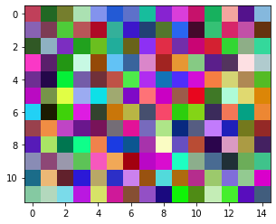

```python
img = np.random.random((12,15,3))
plt.imshow(img);
```

```python
img[0,-1,:]
```

```
array([0.52541756, 0.72342371, 0.86956018])
```

```python
img[:,:,0] # red component of the colors
```

```
array([[0.75606181, 0.13055869, 0.4588423 , 0.67309685, 0.51409798,
        0.13957323, 0.36521496, 0.09306752, 0.53005797, 0.85577713,
        0.78019762, 0.09222959, 0.9556226 , 0.32552943, 0.52541756],
       [0.53475738, 0.49103163, 0.30664944, 0.72758607, 0.68801693,
        0.20771782, 0.23577824, 0.13036134, 0.32225172, 0.16376304,
        0.26977776, 0.21046124, 0.84367708, 0.76326377, 0.40222949],
       [0.19091977, 0.55831752, 0.48720017, 0.13242447, 0.41997422,
        0.13006537, 0.4142859 , 0.55664154, 0.88561363, 0.45202574,
        0.78900733, 0.83167438, 0.19360851, 0.55977269, 0.20579557],
       [0.98257165, 0.35361232, 0.1381914 , 0.78178339, 0.58123918,
        0.38613175, 0.2250626 , 0.85650241, 0.6350867 , 0.9065837 ,
        0.52937129, 0.35855506, 0.32702092, 0.99555953, 0.6923633 ],
       [0.43223635, 0.14155395, 0.02110765, 0.45734368, 0.44337499,
        0.75262418, 0.30647802, 0.69382307, 0.07185598, 0.31178852,
        0.8277407 , 0.96586637, 0.8324609 , 0.68873723, 0.3313082 ],
       [0.73239814, 0.46315778, 0.88301268, 0.61064074, 0.05829983,
        0.6306264 , 0.49887326, 0.99960466, 0.79453145, 0.614042  ,
        0.91116453, 0.24914033, 0.68577261, 0.88094082, 0.86520991],
       [0.13348633, 0.11274891, 0.25045801, 0.87152581, 0.20030387,
        0.79042838, 0.72875698, 0.27788833, 0.97236604, 0.17676904,
        0.51931966, 0.23227305, 0.95477552, 0.01701033, 0.92998997],
       [0.60061018, 0.9428978 , 0.75144899, 0.41620891, 0.47151984,
        0.45787592, 0.88798734, 0.46955844, 0.68270843, 0.03286455,
        0.33902209, 0.76340477, 0.12492888, 0.45714336, 0.58255235],
       [0.33770966, 0.66280864, 0.00310403, 0.06006858, 0.94289727,
        0.10714857, 0.0500074 , 0.65648222, 0.98378243, 0.40570114,
        0.72941138, 0.17138409, 0.85513895, 0.67450283, 0.27044282],
       [0.53965287, 0.55349297, 0.60681553, 0.36552739, 0.96786721,
        0.94589287, 0.63671435, 0.73145011, 0.8526148 , 0.11400023,
        0.55245323, 0.28869665, 0.12929018, 0.42437761, 0.24952278],
       [0.10854405, 0.92925291, 0.38045667, 0.16942631, 0.72762225,
        0.17342691, 0.79910919, 0.60236512, 0.32215221, 0.68353955,
        0.71065078, 0.61235116, 0.50520471, 0.57726781, 0.85333761],
       [0.52516773, 0.70198714, 0.47969245, 0.73071414, 0.84524018,
        0.81459701, 0.52788777, 0.5776115 , 0.10232186, 0.05903435,
        0.3136207 , 0.77034334, 0.27380414, 0.3481087 , 0.2581819 ]])
```

Would like to print the image in red-scale only

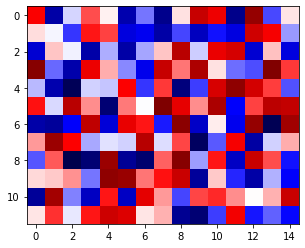

```python
plt.imshow(img[:,:,0],cmap='seismic')
```

```python
r=img.copy()
```

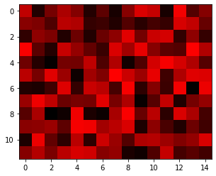

```python
r[:,:,1]=0 # no green
r[:,:,2]=0 # no blue
plt.imshow(r)
```

```python
r[0,1,:]
```

```
array([0.13055869, 0.        , 0.        ])
```

**Ex.** get a green-only and blue-only version of the image

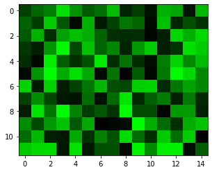

```python
g=img.copy()
g[:,:,0]=0 # no red
g[:,:,2]=0 # no blue
plt.imshow(g)
```

```python
sp=plt.imread("sp.png")
plt.imshow(sp);
sp.shape
```

[output not shown]

```
(333, 900, 4)
```

```python
sp=sp[:,:,0:3]
plt.imshow(sp);
```

[output not shown]

```python
sp[0,0,0]
```

```
0.9529412
```

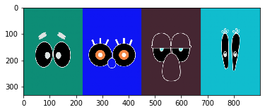

```python
plt.imshow(1-sp);
```

```python
sp=plt.imread("sp.png")
plt.imshow(sp)
low = sp<=0.5
high = sp>0.5
```

```python
sp[low] = sp[low]*1/5
```

[figure not shown]

```python
plt.imshow(sp)
```

```python
sp[high] = ( ( sp[high]-1 ) /5 ) + 1
```

[figure not shown]

```python
plt.imshow(sp)
```

```python
b = plt.imread("bunny.jpg")
print(b[0,0,:]) # check if we are in [0,1] or [0,255]
b=b/255 # to get to the [0,1] interval
print(b[0,0,:])
```

```
[ 7 99 50]
[0.02745098 0.38823529 0.19607843]
```

```python
l=plt.imread("lion.jpg")
print(l[0,0,:]) # check if we are in [0,1] or [0,255]
l=l/255 # to get to the [0,1] interval
print(l[0,0,:])
```

```
[ 49 117  58]
[0.19215686 0.45882353 0.22745098]
```

```python
back1=plt.imread("back1.jpg")
print(back1[0,0,:]) # check if we are in [0,1] or [0,255]
back1=back1/255 # to get to the [0,1] interval
print(back1[0,0,:])
```

```
[132 164  65]
[0.51764706 0.64313725 0.25490196]
```

```python
back2=plt.imread("back2.jpg")
print(back2[0,0,:]) # check if we are in [0,1] or [0,255]
back2=back2/255 # to get to the [0,1] interval
print(back2[0,0,:])
```

```
[ 94 140  78]
[0.36862745 0.54901961 0.30588235]
```

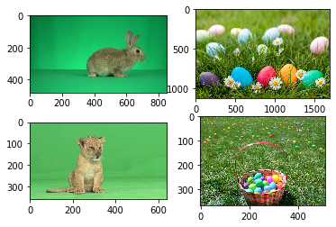

```python
plt.subplot(2,2,1)
plt.imshow(b)
plt.subplot(2,2,2)
plt.imshow(back1)
plt.subplot(2,2,3)
plt.imshow(l)
plt.subplot(2,2,4)
plt.imshow(back2)
```

identify the pixels with a lot of green wrt all the colors (the sum of all colors) for each pixel

```python
x,y,d = l.shape
print(x,y)
```

```
360 640
```

```python
n = back1.copy()
```

```
Clipping input data to the valid range for imshow with RGB data ([0..1] for floats or [0..255] for integers).
```

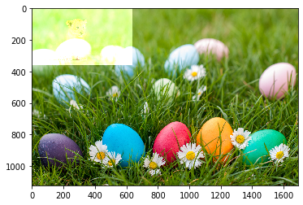

```python
n[:x,:y,:] = n[:x,:y,:] + l
plt.imshow(n)
```

**Ex.**

- post the image of the lion/bunny on black background : 1 point

and/or

- post the image of the lion/bunny on background 1(with eggs) : 2 points.

Post the image on discord, in the channel green, remember to put your name in the title

- `imread` all images ( 3d arrays with RGB)
- take sample points to figure out if we are in [0,1] or [0,255]
- need to find the pixels with a high proportion of green ( `b[:,:,1]/(b.sum(axis=2)` )
- "zero out" all of those pixels
- "zero out" pixels in the background where the bunny/lion would go (careful because they have different sizes)
- combine the two images (+, careful because they have different sizes)

```python
b.shape
```

```
(480, 852, 3)
```

```python
l.shape
```

```
(360, 640, 3)
```

```python
back1.shape
```

```
(1123, 1691, 3)
```

```python
b.shape
```

```
(480, 852, 3)
```

```python
b.sum(axis=2).shape
```

```
(480, 852)
```

## file operations

`open()` allows to open a file (or creates it if it does not exits)

`write` is used to write on the file

`read` is used to read from the file

```python
f=open('grocery.txt',"w") # "w" open to write
f.write("Apples\n")
f.write("eggs\n")
f.write("milk\n")
f.write("Supreme pizza")
f.close()
```

`close()` close the file

```python
pwd
```

```
'C:\\Users\\scassani\\Box\\buffalo_teaching_ubbox\\MTH337_S21'
```

```python
f=open('grocery.txt',"a") # a is for append
f.write('\nchips')
f.close()
```

```python
f=open('grocery.txt','r') # r is for read
grocery = f.read()
f.close()


print(grocery)
```

```
Apples
eggs
milk
Supreme pizza
chips
```

```python
f=open('grocery.txt','r') # r is for read
grocery = f.read()
print(grocery)
print("I've read it")
grocery2=f.read()
print(grocery2)
f.close()
```

```
Apples
eggs
milk
Supreme pizza
chips
I've read it
```

```python
f=open('grocery.txt','r') # r is for read
grocery = f.read()

f.tell()
```

```
40
```

`tell()` return the current position in the string

```python
f.seek(0) # bring the cursor to position set as the variable
f.read()
```

```
'Apples\neggs\nmilk\nSupreme pizza\nchips'
```

```python
f.seek(21)
f.read()
```

```
'upreme pizza\nchips'
```

```python
f.seek(0)
f.read(8)
```

```
'Apples\ne'
```

```python
f.seek(0)
```

```
0
```

```python
f.readlines()# return a list of each line
```

```
['Apples\n', 'eggs\n', 'milk\n', 'Supreme pizza\n', 'chips']
```

```python
f.seek(0)
```

```
0
```

```python
f.readline()
```

```
'Apples\n'
```

```python
f.readline()
```

```
'eggs\n'
```

[output not shown]

```python
f.seek(0)
for line in f:
    print(line)
```

```
Apples

eggs

milk

Supreme pizza

chips
```

```python
f.seek(0)
for k in range(3):
    print(f.readline())
```

```
Apples

eggs

milk
```

```python
f.close()
```